# Iwoca Data Challenge - python version

### My approach would be to fit a logistic regression model, after removing age due to unusual values, I am left with region & sector only. I want to best estimate the role of region and sector in predicting whether a sign up will happen

#### My approach is to split data into final validation and test set. I will then use grid search & cross validation to find hyperparameters for logistic regression which enable parameters which a) best explain error in test set whilst b) ensuring overfitting doesn't occur.

```python
print("Seperate final validation set out and leave aside, and seperately use \ncross validation on 'train' data only to improve model fit")

X = lead_outcome_encode.drop(['Name','sign_up'],axis=1) # Features
y = lead_outcome_encode.sign_up # Target variable

X_train,X_test,y_train,y_test=model_selection.train_test_split(X,y,test_size=0.25,random_state=0)
```

```
Seperate final validation set out and leave aside, and seperately use
cross validation on 'train' data only to improve model fit
```

#### The first model is just a base logistic regression

```python
model = LogisticRegression(fit_intercept = False,verbose=2)
# fit the model with data
model.fit(X_train,y_train)

#
y_pred=model.predict(X_test)
```

```
[Parallel(n_jobs=1)]: Using backend SequentialBackend with 1 concurrent workers.
[Parallel(n_jobs=1)]: Done   1 out of   1 | elapsed:    0.0s remaining:    0.0s
[Parallel(n_jobs=1)]: Done   1 out of   1 | elapsed:    0.0s finished
```

```python
from sklearn import metrics
cnf_matrix = metrics.confusion_matrix(y_test, y_pred)
```

```python
#### The below conf matrix shows me how well logistic
#### regression predicts sign ups.
```

```python
cnf_matrix
```

```
array([[245, 108],
       [142, 185]])
```

```python
print("Accuracy - proportion of total correct predictions:",metrics.accuracy_score(y_test, y_pred).round(2))
print("Precision - proportion of predicted positive outcomes correct:",metrics.precision_score(y_test, y_pred).round(2))
print("Recall - proportion of true positive classified as true:",metrics.recall_score(y_test, y_pred).round(2))
```

```
Accuracy - proportion of total correct predictions: 0.63
Precision - proportion of predicted positive outcomes correct: 0.63
Recall - proportion of true positive classified as true: 0.57
```

#### The model above predicts cases with 63% accuracy (sign ups vs no sign ups). I will try hyper parameter search now to see if I can squeeze a little more performance out.

```python
import time
param_grid = {'dual':[True,False],
              'max_iter':[100,110,120,130,140,200],
              'penalty' : ['l1','l2'],
              'C' : np.logspace(-4, 4, 20)}

grid = model_selection.GridSearchCV(
    estimator=LogisticRegression(fit_intercept = False,verbose=2,penalty = 'penalty'),
    param_grid=param_grid,
    cv = 10,
    n_jobs=-1)

start_time = time.time()
grid_result = grid.fit(X_train, y_train)
# Summarize results
print("Best: %f using %s" % (grid_result.best_score_, grid_result.best_params_))
print("Execution time: " + str((time.time() - start_time)) + ' ms')
```

```
Best: 0.618741 using {'C': 0.08858667904100823, 'dual': False, 'max_iter': 100, 'penalty': 'l2'}
Execution time: 11.091947078704834 ms
```

```
[Parallel(n_jobs=1)]: Using backend SequentialBackend with 1 concurrent workers.
[Parallel(n_jobs=1)]: Done   1 out of   1 | elapsed:    0.0s remaining:    0.0s
[Parallel(n_jobs=1)]: Done   1 out of   1 | elapsed:    0.0s finished
```

#### Now apply cross fold validation to tune parameter estimates

```python
model_hyper_opt = LogisticRegression(
    fit_intercept = False,
    verbose=2,
    dual=False,
    max_iter=100,
    penalty='l2',
    C=0.08858667904100823 )

model_hyper_opt.fit(X_train,y_train)
y_pred_hyp=model_hyper_opt.predict(X_test)
```

```
[Parallel(n_jobs=1)]: Using backend SequentialBackend with 1 concurrent workers.
[Parallel(n_jobs=1)]: Done   1 out of   1 | elapsed:    0.0s remaining:    0.0s
[Parallel(n_jobs=1)]: Done   1 out of   1 | elapsed:    0.0s finished
```

```python
cnf_matrix_hype = metrics.confusion_matrix(y_test, y_pred_hyp)
cnf_matrix_hype
```

```
array([[241, 112],
       [137, 190]])
```

```python
print("Accuracy - proportion of total correct predictions:",metrics.accuracy_score(y_test, y_pred_hyp).round(2))
print("Precision - proportion of predicted positive outcomes correct:",metrics.precision_score(y_test, y_pred_hyp).round(2))
print("Recall - proportion of true positive classified as true:",metrics.recall_score(y_test, y_pred_hyp).round(2))
```

```
Accuracy - proportion of total correct predictions: 0.63
Precision - proportion of predicted positive outcomes correct: 0.63
Recall - proportion of true positive classified as true: 0.58
```

#### A lot of work for little upside! The new model doesn't really improve fit. In reality being constrained by just two categorical factors is likely causing a low ceiling on how we are able to tackle the problem.

## Question 10.2: In what sense are those an optimal criteria set?

#### Based on the constrained universe I have assumed with my model, they are optimal as they give us the best chance of predicting leads for a unknown data set. In reality the prediction power is poor and just beats random chance.

## Question 10.3: How many signups would you expect to get based on those called leads, assuming they were being called by random agents?

```python
leads_full = pd.merge(leads,calls,on='Phone Number',how='left')
leads_full = leads_full[leads_full.isnull().any(1)]
predict_set = leads_full.groupby(['Name','Region','Sector'], as_index=False).agg({}).drop(['Name'],axis=1)

predict_set_encode = pd.get_dummies(predict_set,columns=['Region','Sector'])
predict_set_encode.head()
```

|  | Region_london | Region_midlands | Region_north-east | Region_north-west | Region_northern-ireland | Region_scotland | Region_south | Region_south-east | Region_south-west | Region_wales | Sector_agriculture | Sector_construction | Sector_consultancy | Sector_entertainment | Sector_food | Sector_retail | Sector_wholesale |
| --- | --- | --- | --- | --- | --- | --- | --- | --- | --- | --- | --- | --- | --- | --- | --- | --- | --- |
| 0 | 0 | 0 | 1 | 0 | 0 | 0 | 0 | 0 | 0 | 0 | 0 | 0 | 0 | 0 | 0 | 1 | 0 |
| 1 | 0 | 1 | 0 | 0 | 0 | 0 | 0 | 0 | 0 | 0 | 0 | 0 | 0 | 0 | 1 | 0 | 0 |
| 2 | 0 | 0 | 0 | 0 | 0 | 0 | 1 | 0 | 0 | 0 | 0 | 1 | 0 | 0 | 0 | 0 | 0 |
| 3 | 0 | 0 | 0 | 0 | 0 | 0 | 1 | 0 | 0 | 0 | 0 | 0 | 0 | 0 | 1 | 0 | 0 |
| 4 | 0 | 0 | 1 | 0 | 0 | 0 | 0 | 0 | 0 | 0 | 0 | 0 | 0 | 1 | 0 | 0 | 0 |

```python
sorted_next_1000 = pd.DataFrame(model_hyper_opt.predict_proba(predict_set_encode))[1].sort_values(ascending=False)[:1000]

print("{} leads!".format(round(sum(sorted_next_1000))))
```

```
682 leads!
```

## (Extra) Finding most appropriate way to assess best model

```python
outcome_pred = pd.DataFrame(
    {'Outcome': y_test.reset_index(drop=True),
     'Prediction':pd.DataFrame(model_hyper_opt.predict_proba(X_test))[1]
    }
).sort_values('Prediction',ascending=False).reset_index(drop=True)
outcome_pred.head()
```

|  | Outcome | Prediction |
| --- | --- | --- |
| 0 | 1 | 0.755702 |
| 1 | 1 | 0.755702 |
| 2 | 1 | 0.755702 |
| 3 | 1 | 0.755702 |
| 4 | 0 | 0.738756 |

```python
# Summary metric 1 - beating random

def model_beats_random(df):
    random_choice = []
    cumsum_col = df.Outcome.cumsum()
    s = list(range(len(df)))
    random.shuffle(s)
    for i in s:
        random_choice.append(df.Outcome[i])
    rand_series = pd.Series(random_choice).cumsum().reset_index(drop=True)
    plt.plot(range(len(df)),rand_series,label="random_choice")
    plt.plot(range(len(df)),cumsum_col,label="logistic_order_choice")
    plt.legend()
    plt.xlabel('Lead Choice Count')
    plt.ylabel('No of Sign Ups Achieved')
    return plt.show()
```

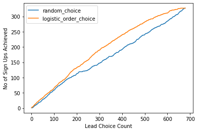

```python
model_beats_random(outcome_pred)
```

```
0.6825939305732429
```

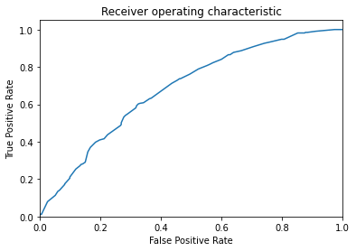

```python
fpr = dict()
tpr = dict()
roc_auc = dict()
fpr, tpr, _ = metrics.roc_curve(outcome_pred.Outcome,outcome_pred.Prediction)
roc_auc = metrics.auc(fpr, tpr)

print(metrics.roc_auc_score(outcome_pred.Outcome, outcome_pred.Prediction))
plt.figure()
plt.plot(fpr, tpr)
plt.xlim([0.0, 1.0])
plt.ylim([0.0, 1.05])
plt.xlabel('False Positive Rate')
plt.ylabel('True Positive Rate')
plt.title('Receiver operating characteristic')
plt.show()
```

```python
print('AUC of 0.68 gives us prob randomly select signed up lead will have a \nhigher prediction compared to a randomly selected negative lead')
print("\n")
print("Given this definition of AUC, AUC feels like a very appropriate summary measure for this problem")
```

```
AUC of 0.68 gives us prob randomly select signed up lead will have a
higher prediction compared to a randomly selected negative lead


Given this definition of AUC, AUC feels like a very appropriate summary measure for this problem
```

## Question 10.4: If you could choose the agents to make those calls, who would you choose? Why?

```python
# My first thoughts on this to lay out what we have learned so far from the agents
# 1: Some agents make more calls than others
# 2: Agents have different amounts of calls per sign ups (overall efficiency)
```

```python
# Things we don't really know
# How does an earlier call impact decision to use another agent?
# How much time to the agents have for this job alone?
# How available are agents for a call after a previous call?
# How likely is a dead line? Can we predict these?
```

## Proposed solution

#### I personally can't answer the question without having more information available, or more guidance. Without that I would proceed to try and model the situation using Bayesian Networks.

## Pre work

#### Assuming agents are available purely based on their own time constraint, model agent avaialability at any time T via a poisson process.

#### Build a model to predict dead line likelihood based on region & sector

## Main model

#### 1) Build a graph of the relations between the known variables

#### 2) Fit a Bayesian Network to this known graph (including dead line prediction).

#### 3) At time 0, assume all agents available and assign agents to leadssuch that total probability of lead conversion is maximised across all 5 calls. (this involves calculating conditional probability for each agent/lead combo).

#### 4) For each individual lead, if dead line / sign up / not interested then remove from sample

#### 5) if not, add back to sample and add a multiple call flag.

#### 6) repeat until all samples have been concluded

## Notes on the above

#### directed acyclic graph requires all conditional probabilities to be explicitly added.

#### I would probably assume agent choice is conditionally independent of the leads data (region, sector) to simplify the graph somewhat.